{% raw %}

# Online Dashboards with Excel, Python & Plotly

#### ABOUT THE AUTHOR:

This notebook was contributed by [Plotly user Otto Stegmaier](https://plotly.com/~otto.stegmaier). You can follow Otto on [GitHub](https://github.com/ostegm).

#### Building Interactive Graphs at the Push of an (Excel) Button Using Plot.ly and xlwings

This notebook is a primer on building interacitve web-based visualizations straight from an excel workbook with

- [pandas](http://pandas.pydata.org/): A library with easy-to-use data structures and data analysis tools. Also, interfaces to out-of-memory databases like SQLite.
- [Ipython notebook](http://ipython.org/notebook.html): An interface for writing and sharing python code, text, and plots.
- [xlwings](http://xlwings.org/): A python library with tools to connect pandas to data stored in excel workbooks.
- [Plot.ly](https://plotly.com/): A platform for publishing beautiful, interactive graphs from Python to the web.

###### In Short... How you can go from this:

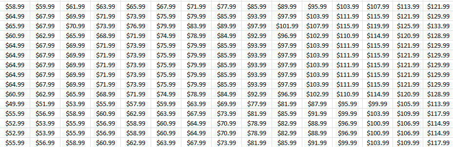

```python
from IPython.display import Image
Image(filename='xlwings_assets/prices.png', width = 700)
```

###### To this:

```python
import plotly.tools as tls
tls.embed('https://plotly.com/~otto.stegmaier/609/previous-min-and-max-prices/')
```

[interactive chart not shown]

[figure not shown]

```python
Image(filename='xlwings_assets/logo.png')
```

###### *Why* we are working on this:

At [Liftopia](http://www.liftopia.com/) we are working on bringing dynamic pricing into the ski industry. We help consumers ski more by offering tickets for purchase in advance at lower prices in exchange for their commitment. We help resorts control their pricing, drive more predictable revenue and grow their businesses.

Since one of our core business channels is pricing and selling lift tickets for our resort partners, our analytics team needs to be able to communicate our pricing plans to our resort partners in a simple, but effective manner. The ski areas we work with often offer tickets on 120 days of the year at upwards of 10 different price points on each day of the season. If you do the math - that can mean trying to communicate 1,200 different prices for one product. Some resorts offer over 10 different products. Now we are at 12,000 data points. Want to see the junior and child ticket pricing too? Now that's 36,000 data points.

In an effort to communicate our pricing plans more effecitvely - we decided to use [Plot.ly](https://plotly.com/) to help us build web based interactive visualizations we can share with our partners. To do this we connected one of our pricing tools to a python script that interacts with Plotly's API.This notebook walks through a simplified version of that process. Note - the data used in this example is intended to show how we use Plotly from Excel - if you want to talk to us about our beliefs abour pricing - get in touch! (ostegmaier@liftopia.com)

###### Covered in this notebook

- Connect to an excel workbook with XLWings
- Clean and prepare your data with pandas
- Plot with Plotly
- Building the VBA connection to your python code
- Sharing and Collaborating with Plotly

### Step 1: Connect to your data in Excel using xlwings

To show how we use plotly with XLWings and Excel - we put together some simulated data in an excel workbook. For more on XLWings Check out their [documentation](http://docs.xlwings.org/api.html) or this [great tutorial](https://www.youtube.com/watch?v=Z80kyLcG6JI)

```python
from IPython.display import IFrame
#A few imports we will need later
from xlwings import Workbook, Sheet, Range, Chart
import pandas as pd
import numpy as np
import plotly.plotly as py
import plotly.tools as tlsM
from IPython.display import HTML
from plotly.graph_objs import *
```

```python
#workbook connection - When connecting to a file from a VBA macro you use Workbook.call() instead of Workbook(<filepath>)
wb = Workbook('xlwings_assets/Example Workbook.xlsm')
```

Using Excel as a Plotly Dashboard...

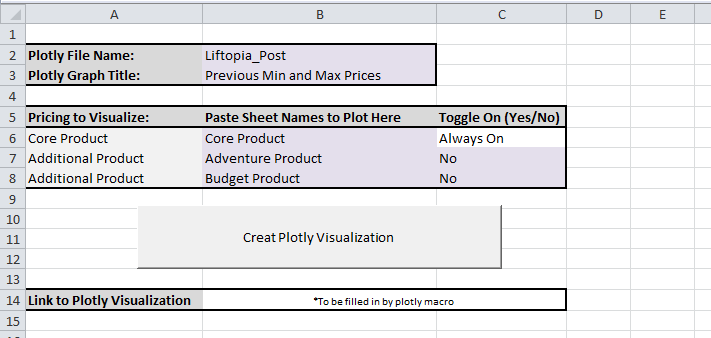

```python
Image(filename="xlwings_assets/dashboard.png", width="700")
```

Now we can use some of these user-input values to control what elements get plotted

```python
#Now we can use some of these controls to customize the
folder_name = Range('Dashboard','B2').value
graph_title = Range('Dashboard','B3').value
```

### Step 2: Clean and prepare your data for plotting using Pandas

To show how we use plotly with XLWings and Excel - we put together some simulated data in an excel workbook. For more on XLWings check out their [documentation](http://docs.xlwings.org/api.html) or this [great tutorial](https://www.youtube.com/watch?v=Z80kyLcG6JI)

```python
#short function to create a new dataframe using xlwings
def new_df(shtnm, startcell = 'A1'):
    data = Range(shtnm, startcell).table.value
    temp_df = pd.DataFrame(data[1:], columns = data[0])
    return(temp_df)

###Make some dataframes from the workbook sheets
#Core Product
shtnm1 = Range('Dashboard','B6').value
df = new_df(shtnm1)
```

Based on user input from the "dashboard" sheet in excel - we can choose to create a new dataframe for the 2nd product

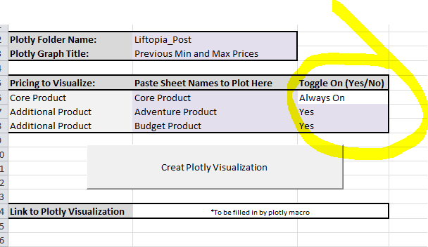

```python
Image(filename="xlwings_assets/toggle.png", width="600")
```

```python
#2nd Product
product_2 = False
if Range('Dashboard','C7').value == "Yes":
    shtnm2 = Range('Dashboard','B7').value
    df2 = new_df(shtnm2)
    product_2 = True
```

```python
#3rd Product
product_3 = False
if Range('Dashboard','C8').value == "Yes":
    shtnm3 = Range('Dashboard','B8').value
    df3 = new_df(shtnm3)
    product_3 = True
```

Its easier to work with the column headers once they're cleaned up, so let's clean them up a bit

```python
#Clean up the charaters in the columns
names2 = []
def clean_names(column_list):
    #Short function to make our column headers easier to reference later.
    names2=[]
    for name in column_list:
        name = name.replace(" ","").lower()
        names2.append(name)
    return names2
```

```python
df.columns = clean_names(df.columns.values)
if product_2 == True:
    df2.columns = clean_names(df2.columns.values)
if product_3 == True:
    df3.columns = clean_names(df3.columns.values)
```

We found it useful to be using a common index across the products - at least for our purpose, so we reset the index on the date column and convert the rest of the data to float

```python
df= df.set_index('date').tz_localize('MST').astype(float)
if product_2 == True:
    df2= df2.set_index('date').tz_localize('MST').astype(float)
if product_3 == True:
    df3= df3.set_index('date').tz_localize('MST').astype(float)
```

### Step 3: Plot your data with plotly

```python
#set a few global variables so we can use them throughout the plots
X = df.index

try:
    ymin = min(df['minpriceoffered'].min(),df2['minpriceoffered'].min(),df3['minpriceoffered'].min()) - 10
    ymax = max(df['walkupprice'].max(),df2['walkupprice'].max(),df3['walkupprice'].max()) + 10

except:
    #If that doesn't work, just go edit it on Plotly's web based plot editor.
    ymin = df['minpriceoffered'].min() - 10
    ymax = df['walkupprice'].max() + 10
```

For our particular use case - we were rebuilding traces of similar type, so we wrote a short function to simplify this step

```python
#function to create a "trace" (line) for each item we want to plot
def new_trace(price_column, color, name, x=X, fill = 'none', qty_column = []):
    trace = Scatter(
    x=X,
    y=price_column,
    fill=fill,
    mode='lines',
    name=name,
    text=['Quantity: {}'.format(q) for q in qty_column],
    line=Line(
        color=color,
        width=2,
        dash='solid',
        opacity=1,),
    xaxis='x1',
    yaxis='y1')
    return trace

#Set up the 3 core traces
trace1 = new_trace(df['walkupprice'], '#FF9966','Core Product Walkup Price')
trace2 = new_trace(df['maxpriceoffered'], '#5EA5D1',shtnm1 + 'Highest Price Offered', qty_column=df['unitsmax'])
trace3 = new_trace(df['minpriceoffered'], '#5EA5D1',shtnm1+' Starting Price',  qty_column= df['unitsmin'], fill='tonexty')
trace_list = [trace1, trace2, trace3]
```

```python
#add additional traces if toggled on by user
if product_2 == True:   #Using the input from the Dashboard Sheet in Excel
    trace4 = new_trace(df2['minpriceoffered'], '##66ff66',shtnm2+' Lowest Price Offered')
    trace_list.append(trace4)

if product_3 == True:   #Using the input from the Dashboard Sheet in Excel
    trace5 = new_trace(df3['minpriceoffered'], '#e6e600',shtnm3+' Lowest Price Offered')
    trace_list.append(trace5)
```

Lastly we set some general Layout controls. If needed, these could be added as user controls pretty easily in the Excel dashboard - or you could just edit the graph from Plotly's GUI.

```python
y_axis = YAxis(
        title='Price',
        titlefont=Font(
            size=11.0,
            color='#262626'
        ),
        range=[ymin, ymax],
        domain=[0.0, 1.0],
        type='linear',
        showgrid=True,
        zeroline=False,
        showline=True,
        nticks=7,
        ticks='inside',
        tickfont=Font(
            size=10.0
        ),
        mirror='ticks',
        anchor='x1',
        side='left'
    )
```

```python
x_axis = XAxis(
        title='Trip Date',
        titlefont=Font(
            size=11.0,
            color='#262626'
        ),
        range=[X.min(),X.max()],
        domain=[0.0, 1.0],
        type='date',
        showgrid=True,
        zeroline=False,
        showline=True,
        nticks=8,
        ticks='inside',
        tickfont=Font(
            size=10.0
        ),
        mirror='ticks',
        anchor='y1',
        side='bottom'
    )
```

```python
layout = Layout(
    title=graph_title,  #Using the input from the Dashboard Sheet in Excel
    titlefont=Font(
        size=12.0,
        color='#262626'
    ),
    showlegend=True,
    hovermode='compare',
    xaxis1= x_axis,
    yaxis1= y_axis
)
```

```python
#Short function for pushing private graphs to plotly
def private_plot(*args, **kwargs):
    kwargs['auto_open'] = False     #Controls whether a new tab is opened in your browser with the new plot
    url = py.plot(*args, **kwargs)
    return (url)
```

Now We are ready to plot!

```python
fig = Figure(data=trace_list, layout=layout)
url = private_plot(fig,  filename='%s/%s' %(folder_name, graph_title), sharing='public')
tls.embed(url)
```

[interactive chart not shown]

### Step 4: Running your python code directly from Excel

- Save the python script to file. Make sure to use Workbook.caller() rather than the file path. This allows XLWings to access the current notebook that the user has open.

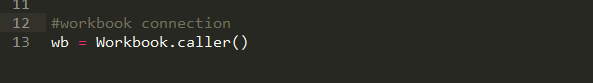

```python
Image(filename= 'xlwings_assets/workbookcaller.png', width="500")
```

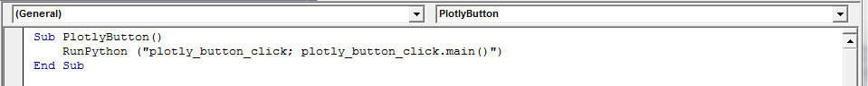

```python
Image(filename= "xlwings_assets/macro.png", width="700")
```

- Assign the macro to a button of your choosing

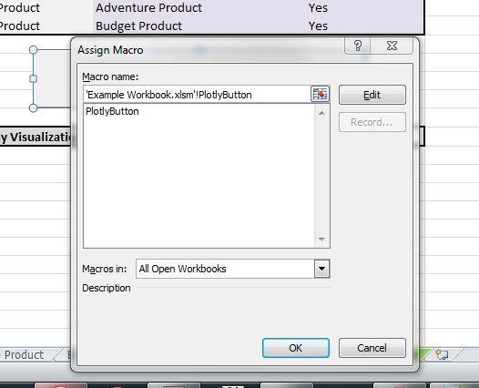

```python
Image(filename= "xlwings_assets/assignmacro.png", width="500")
```

- Make any final edits using Plotly's web based editor, Workspace

[figure not shown]

```python
Image(filename= "xlwings_assets/plotlyeditor.png", width="800")
```

### Step 5: Sharing your work and Collaborating with Others

One of the main reasons we wanted to use Plotly was the ability to share these interacitve visualizations via a URL. This makes it easy for our account managers to communicate the pricing plans with a simple email containging a link to the plot.

Plotly has built out some great functionality that makes sharing and collaborating really easy. When we have multiple analysts on a pricing build we can all work on a plot and once its done, its easy to share a private link with our partners. To learn more about Plotly sharing and privacy check out Plotly Getting Started and [this tutorail on Plotly privacy settings](https://plotly.com/python/privacy/)

[figure not shown]

```python
Image(filename='xlwings_assets/sharing.png')
```

{% endraw %}